# MTH6139 Time Series CW1

Coursework 1 – 231173052

Elliott Stoute

Spring term 2026

# Section 0: Overview

This is the MTH6139 Time Series Coursework 1 based on time series data of Australian Beer production from 1990 to 1995. I have done this using Meta’s Prophet R package.Prophet is a forecasting package typically used for time series data.Data is in Mega Litres.

# Section 1: R Code

I ran “install.packages(”remotes”)” and “remotes::install_github(‘facebook/prophet@*release’, subdir=‘R’)” in the console first. Hence I have iused the latest version of Meta’s Prophet.

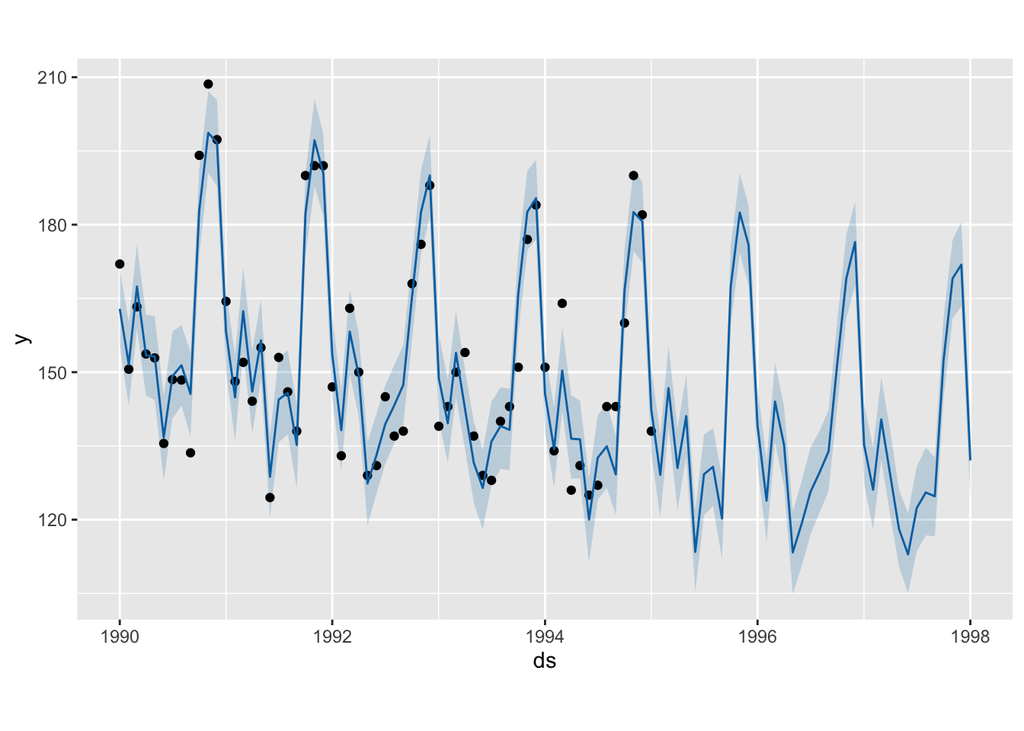

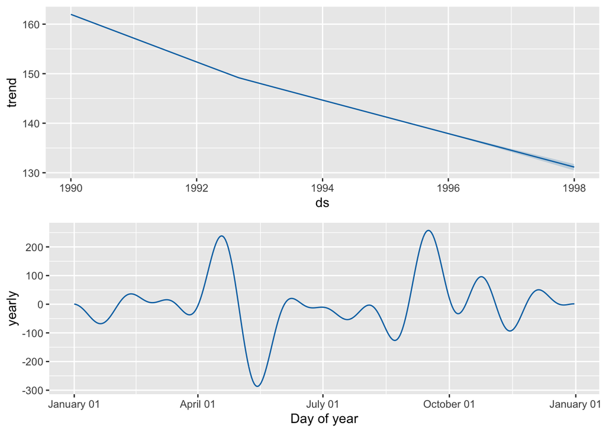

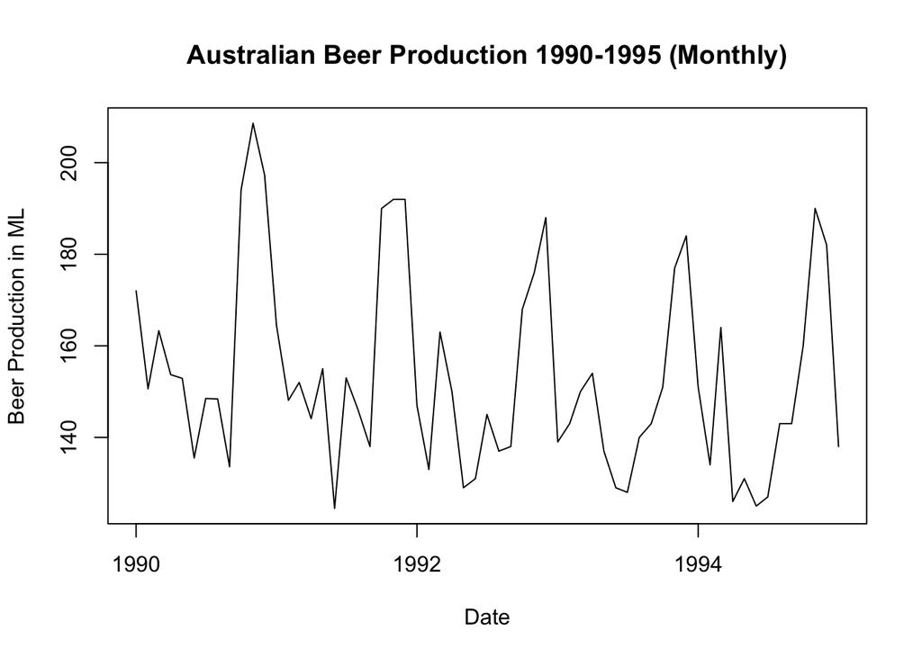

## Section 1.1 Explanation

I start out by loading the Meta Prophet package in R using the most updated version. Initially the data goes back to January 1956 but this was too large of a data set so I sub set the data to cover 1990-1995 (the last 5 years of the data). Then I had to edit the CSV file in excel to change the date label to ds and production header to y to fit the prophet format. And appending the date to then be YYYY-MM-DD by adding “-01” to the ds column which added the “-DD”.

Moving onto the use of Prophet, I use the prophet fucntion from the prophet library based on the AusBeerProd data with only Yearly seasonality being held TRUE. Use of additive seasonality as seasonality between trend cycle is consistent over the 5 years.

FutureDates makes a data frame that adds 36 periods which is 36 months worth of data points to the beer data. The Predict function then uses such points and the fitted model to forecast future results.

I then plot the forecast data and its components to compare seasonality.

# Section 2: Plots

## Section 2.1 Meta Prophet Plots

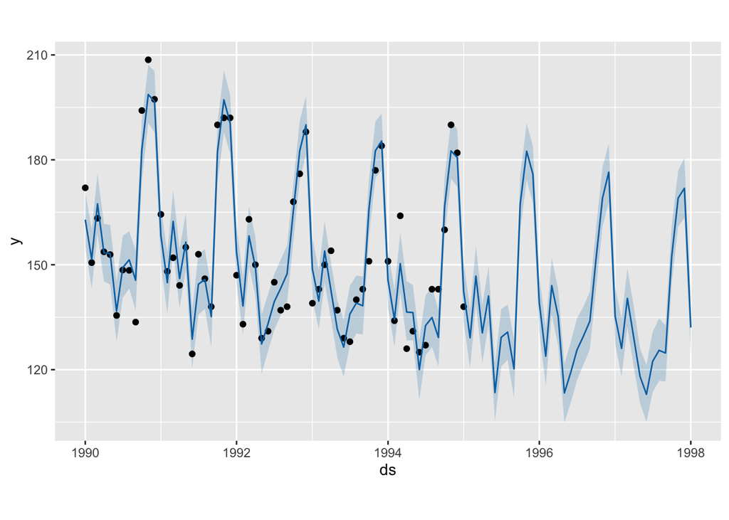

```r
plot(AusBeerProdModel, AusBeerProdForecast)
```

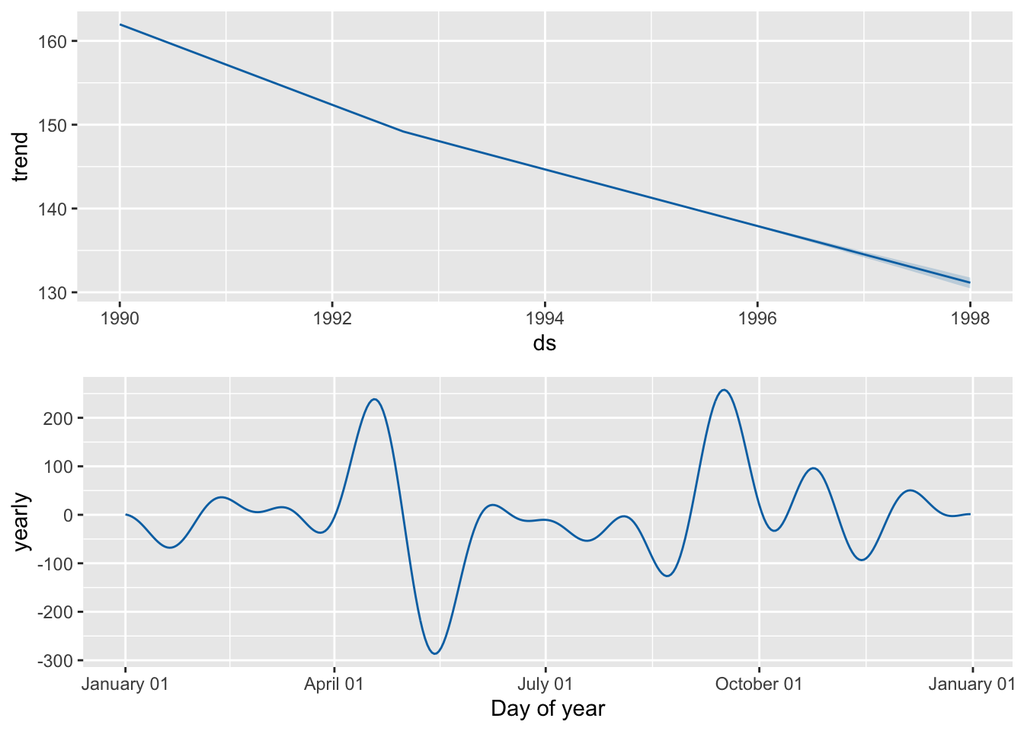

```r
prophet::prophet_plot_components(AusBeerProdModel, AusBeerProdForecast)
```

## Section 2.2 Raw Data Plot

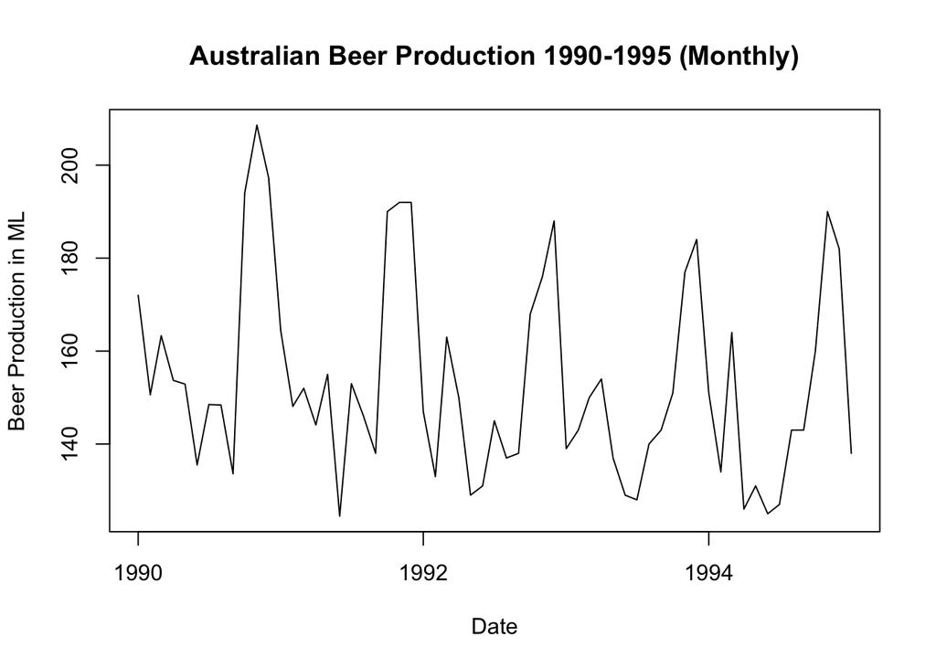

```r
#Plot of raw data
plot(AusBeerProd,type = "l", xlab ="Date", ylab="Beer Production in ML", main = "Australian Beer Production 1990-1995 (Monthly)")
```

# Links

- Intro to Prophet: https://facebook.github.io/prophet/docs/quick_start.html#r-api
- Project GitHub: https://github.com/ElliottStoute/MTH6139-Time-Series-Coursework-1
- Data Source: https://www.kaggle.com/code/mpwolke/australian-monthly-beer-production/input?select=dataset
- Datacamp course: https://www.datacamp.com/courses/reporting-with-rmarkdown
- RStudio reference: https://rmarkdown.rstudio.com/lesson-1.html
- More sophisticated reference: https://bookdown.org/yihui/rmarkdown/